# CHEATING THE YOUTUBE SYSTEM???

Trending Youtube Video Analysis (NOT CLICKBAIT!!!)

Group 5: Taylor Buske, Kailee Ervin, Derek Thada, and Saiyothin Vongpanya

5/1/2020

# Introduction

## About our data:

```r
youtube <- read_csv("https://raw.githubusercontent.com/frost2351/stat480/master/youtube.csv")
```

We used trending YouTube data found on Data World that had all trending videos from November 14, 2017, to June 14, 2018, in each of the four countries: Canada, France, Great Britain and the United States.

Our data had 161,470 records and the 17 variables: `video_id`, `trending_date`, `title`, `channel_title`, `category_id`, `publish_date`, `time_frame`, `published_day_of_week`, `publish_country`, `tags`, `views`, `likes`, `dislikes`, `comment_count`, `comments_disabled`, `ratings_disabled`, and `video_error_or_removed`.

For our analysis we initially did some data cleaning, inlcuding changing some variable data types (`trending_date` from factor to date type variable), reordering certain factors in more meaningful orders (`published_day_of_week` to start on Monday and end on Sunday), and recoded `category_id` to be the actual category titles.

## About YouTube’s Trending Video List

According to YouTube’s own help page, there are various factors on how a video becomes trending, including:

- Videos must not be misleading, clickbaity, or sensational.
- Most relevant of users and reflective of broad content on platform
- Shows diversity of creators

However, these don’t explicitly explain how YouTube’s algorithm works, so we decided to investigate:

**What are the characteristics that make a trending YouTube video?**

# Dates and Times

## About `trending_date`

Each row in our data corresponds to a video on a specific trending date. Therefore, if a video appears multiple times in our dataset, it has been trending for multiple days.

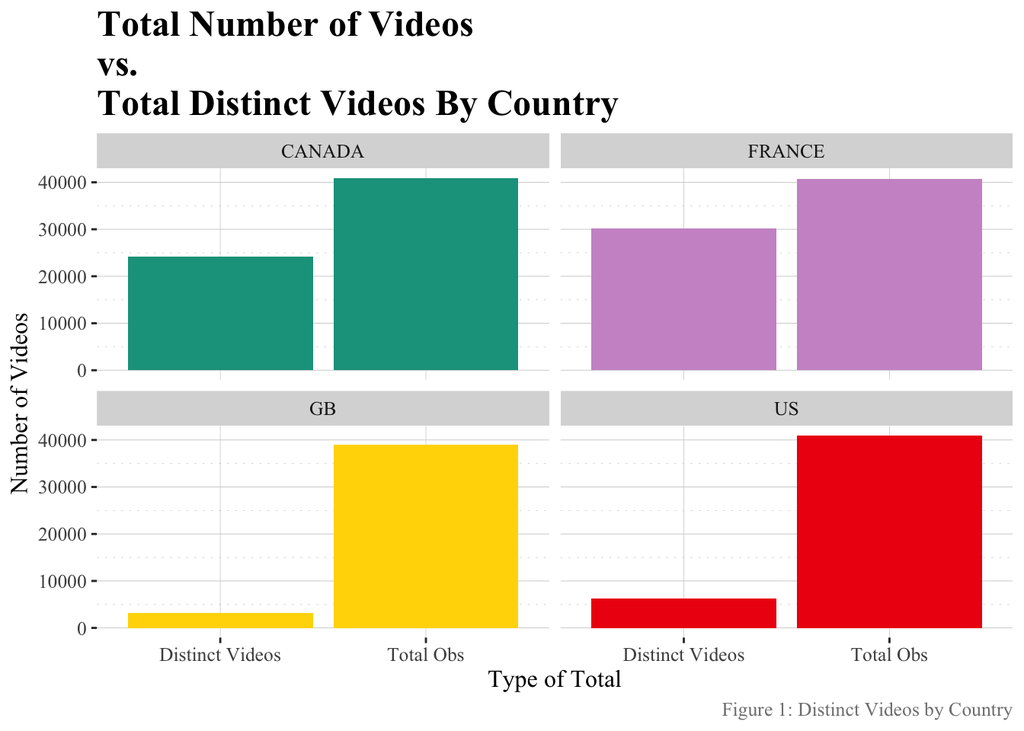

```r
youtube %>%
  group_by(publish_country) %>%
  mutate(total_video=n()) %>%
  distinct(video_id, .keep_all=TRUE) %>%
  summarise(`Distinct Videos`=n(),
            `Total Obs`=mean(total_video)) %>%
  pivot_longer(cols=`Distinct Videos`:`Total Obs`,
               names_to="total_type",
               values_to="number_videos") %>%
  ggplot(aes(x=total_type, fill=publish_country))+
  scale_fill_discrete(name="Publish Country")+
  geom_bar(aes(weight=number_videos), show.legend = FALSE)+
  facet_wrap(~publish_country)+
  labs(title="Total Number of Videos \nvs. \nTotal Distinct Videos By Country", y="Number of Videos", x="Type of Total", caption= "Figure 1: Distinct Videos by Country")
```

In Figure 1, I compare the total number of observations of trending videos in each country to their number of distinct videos. As you can see, the total observations for each country are relatively equal but, number of distinct videos is drastically different. For Canada and France, there are more distinct videos compared to Great Britain and the United States. Therefore, while Canada and France have more distinct videos, their videos are not on the trending list for very long. In comparison, Great Britain and the US have less distinct videos that are on the trending list a lot longer. For comparison purposes, I will be using proportions of total distinct videos in each country.

## What are the popular hours to publish?

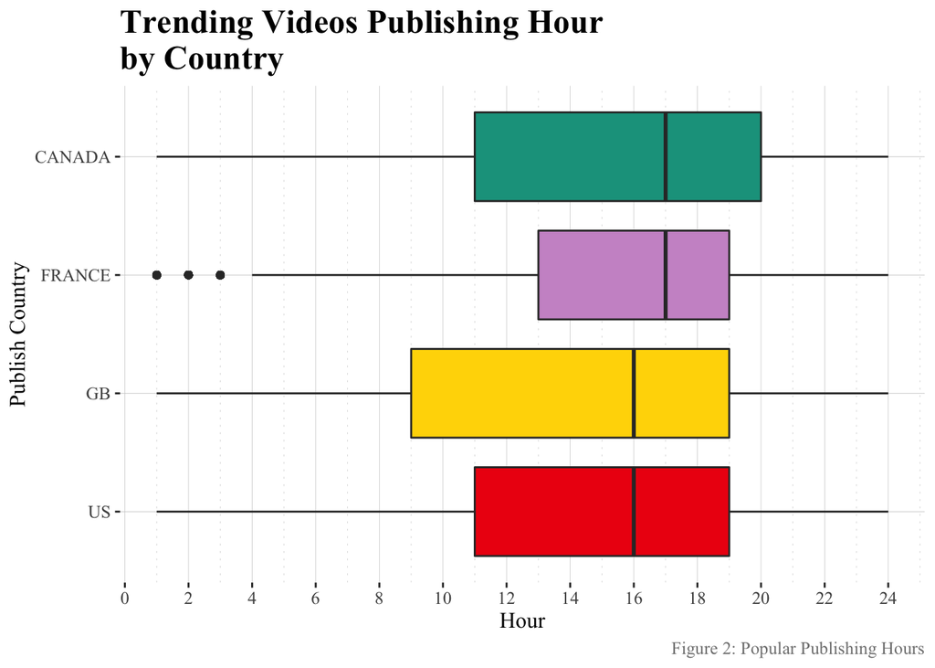

```r
youtube %>%
  mutate(hour=recode(time_frame, "0:00 to 0:59"="1","1:00 to 1:59"="2","2:00 to 2:59"="3",
                                          "3:00 to 3:59"="4","4:00 to 4:59"="5","5:00 to 5:59"="6",
                                          "6:00 to 6:59"="7","7:00 to 7:59"="8","8:00 to 8:59"="9",
                                          "9:00 to 9:59"="10","10:00 to 10:59"="11","11:00 to 11:59"="12",
                                          "12:00 to 12:59"="13","13:00 to 13:59"="14","14:00 to 14:59"="15",
                                          "15:00 to 15:59"="16","16:00 to 16:59"="17","17:00 to 17:59"="18",
                                          "18:00 to 18:59"="19","19:00 to 19:59"="20","20:00 to 20:59"="21",
                                          "21:00 to 21:59"="22","22:00 to 22:59"="23","23:00 to 23:59"="24"),
         hour=as.character(hour),
         hour=as.integer(hour)) %>%
  ggplot(aes(x=publish_country, y=hour))+
  geom_boxplot(aes(fill=publish_country), show.legend=FALSE)+
  scale_y_continuous(breaks=seq(0,24,2))+
  scale_x_discrete(limits=c("US", "GB", "FRANCE", "CANADA"))+
  coord_flip()+
  labs(title="Trending Videos Publishing Hour \nby Country", x="Publish Country", y="Hour", caption="Figure 2: Popular Publishing Hours")
```

The variable time_frame is the hour that a video is published. This variable takes into account time zones, so the corresponding time_frame is based on the local time of wherever the video was published.

Canada and France have the same median publishing hour at around 5pm. However, France is the only country with outliers at hours 1, 2, and 3. Great Britain and the United States also seem to be similar as they have the same median publishing hour at around 4pm.

## What are the popular days of the week to publish?

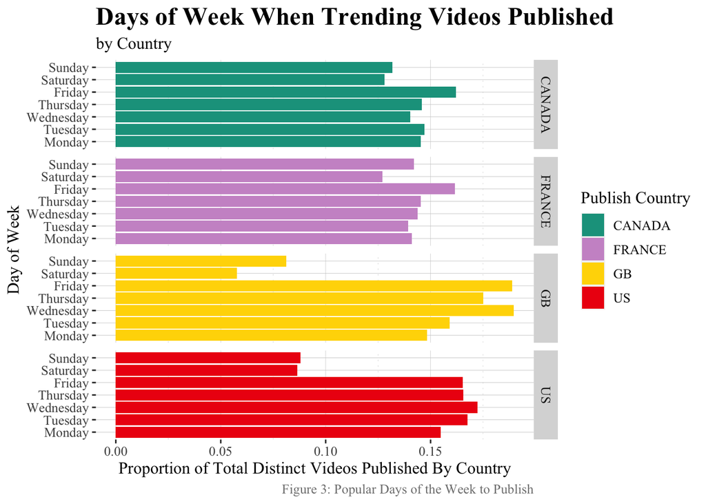

```r
youtube %>%
  group_by(publish_country) %>%
  distinct(video_id, .keep_all=TRUE) %>%
  mutate(distinct_videos=n()) %>%
  group_by(publish_country, published_day_of_week) %>%
  summarise(time_frame_total=n(),
            distinct_videos=mean(distinct_videos)) %>%
  mutate(time_frame_prop=case_when(publish_country=="CANADA"~time_frame_total/distinct_videos,
                                      publish_country=="FRANCE"~time_frame_total/distinct_videos,
                                      publish_country=="GB"~time_frame_total/distinct_videos,
                                      publish_country=="US"~time_frame_total/distinct_videos)) %>%
  ggplot(aes(x=published_day_of_week, fill=publish_country))+
  scale_fill_discrete(name="Publish Country")+
  geom_bar(aes(weight=time_frame_prop))+
  facet_grid(publish_country~.)+
  labs(x="Day of Week", y="Proportion of Total Distinct Videos Published By Country", title="Days of Week When Trending Videos Published", subtitle="by Country", caption="Figure 3: Popular Days of the Week to Publish")+
  coord_flip()
```

Looking at Figure 3, Canada and France don’t seem to have any significant preferences on which day of the week they publish their trending videos.

However, both Great Britain and the United States seem to prefer publishing more on weekdays and less on weekends. This result could correspond to the preferences of posting later in the day. As people start getting off work or done with school activities around 4 to 5pm YouTube becomes a popular pastime and creators might take advantage of this time in order to increase their rate of views.

## How long does it take to for a video to become trending?

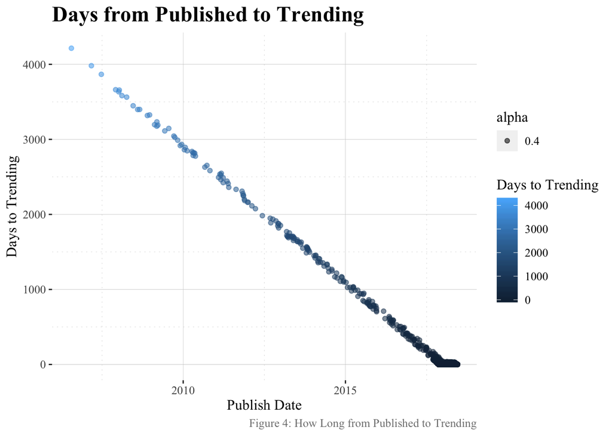

```r
youtube_trend<-youtube %>%
  select(video_id, publish_date, trending_date) %>%
  group_by(video_id, publish_date) %>%
  summarise(first_trend=min(trending_date)) %>%
  mutate(days_to_trend=(publish_date %--% first_trend)/ddays(1)) %>%
  ungroup()

youtube_trend %>%
  ggplot(aes(x=publish_date, y=days_to_trend, color=days_to_trend))+
  scale_color_continuous(name ="Days to Trending")+
  geom_point(aes(alpha=0.4))+
  labs(title="Days from Published to Trending", x="Publish Date", y="Days to Trending", caption="Figure 4: How Long from Published to Trending")
```

In Figure 4, We looked at how many days it takes for a video to first appear on the trending list from when it was published.

As a reminder, our data includes all trending videos between November 2017 through June 2018. While our trending date period is relatively narrow, the publishing dates are from 2006 to 2018. Therefore, some videos take a long time to become trending.

```r
youtube_trend %>% summarise(mean_days_to_trend=mean(days_to_trend))
```

```
## # A tibble: 1 x 1
##   mean_days_to_trend
##                <dbl>
## 1               7.13
```

However, on average it takes a week for a video to become trending once published.

We will take a closer look at publishing dates before and during our trending period that starts on November 14, 2017.

### Taking a closer look: July 23, 2006 to November 14, 2017

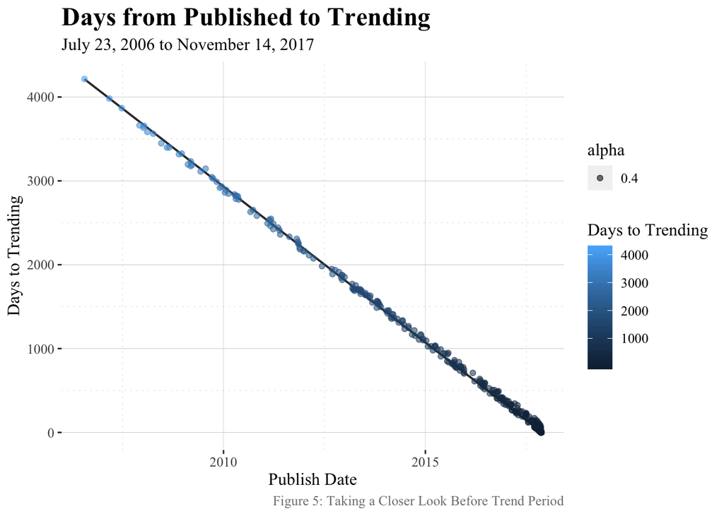

```r
youtube_old<-youtube_trend %>%
  filter(publish_date<"2017-11-14")

youtube_old %>%
  ggplot(aes(x=publish_date, y=days_to_trend, color=days_to_trend))+
  scale_color_continuous(name ="Days to Trending")+
  geom_smooth(method = "lm", color="grey20", alpha=0.3, size=0.7, se=FALSE)+
  geom_point(aes(alpha=0.4))+
  labs(title="Days from Published to Trending", subtitle="July 23, 2006 to November 14, 2017",x="Publish Date", y="Days to Trending", caption="Figure 5: Taking a Closer Look Before Trend Period")
```

When we look at videos that were published before our trending period in Figure 5, we can see a very strong negative linear relationship between when the video was published and how many days it takes for that video to become trending.

```r
# Videos before Trend
youtube_trend %>%
  filter(publish_date<"2017-11-14") %>%
  summarise(videos_before_trend=n())
```

```
## # A tibble: 1 x 1
##   videos_before_trend
##                 <int>
## 1                1115
```

```r
# Total Videos
youtube_trend %>%
  summarise(total_videos=n())
```

```
## # A tibble: 1 x 1
##   total_videos
##          <int>
## 1        56106
```

However, the number of videos published before November 14, 2017 is only 2% of all the videos published in this dataset so it is a relatively small subset.

### Taking a closer look: November 14, 2017 to June 14, 2018

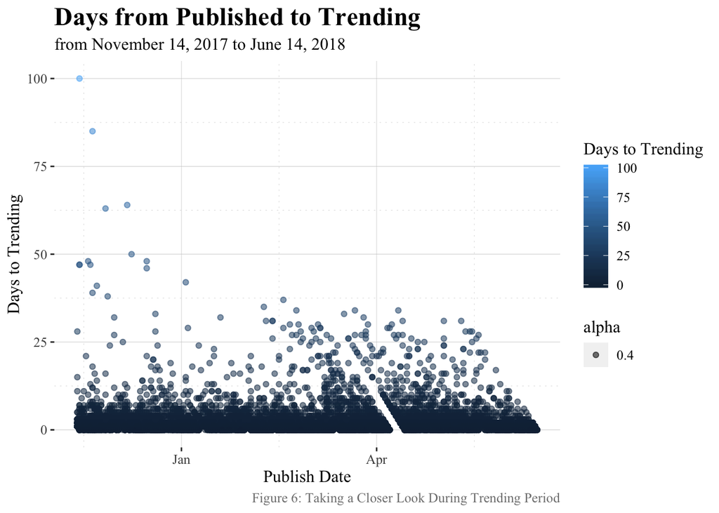

```r
youtube_trend %>%
  filter(publish_date>="2017-11-14") %>%
  ggplot(aes(x=publish_date, y=days_to_trend, color=days_to_trend))+
  scale_color_continuous(name="Days to Trending")+
  geom_point(aes(alpha=0.4))+
  labs(title="Days from Published to Trending",subtitle="from November 14, 2017 to June 14, 2018", x="Publish Date", y="Days to Trending", caption="Figure 6: Taking a Closer Look During Trending Period")
```

Looking at Figure 6, most videos in this dataset only take a couple days to become trending as seen with the thick dark blue along the x axis.

```r
youtube_trend %>%
  filter(publish_date>="2017-11-14") %>% summarise(mean_days_to_trend=mean(days_to_trend))
```

```
## # A tibble: 1 x 1
##   mean_days_to_trend
##                <dbl>
## 1               1.33
```

If you calculate the mean number of days to trending just within the trending period, you only get 1.3 days which is less than the 7 days average number of days to trending for all videos. That means those videos published before the trending period are influencing our average.

There is also a distinct blank line in the data around April.

```r
youtube %>%
  arrange(trending_date) %>% group_by(trending_date) %>% summarise(nbr_trending_videos=n()) %>% filter(trending_date>="2018-04-01", trending_date<="2018-04-30") %>% slice(1:10)
```

```
## # A tibble: 10 x 2
##    trending_date nbr_trending_videos
##    <date>                      <int>
##  1 2018-04-01                    780
##  2 2018-04-02                    780
##  3 2018-04-03                    789
##  4 2018-04-04                    786
##  5 2018-04-05                    792
##  6 2018-04-06                    798
##  7 2018-04-07                    794
##  8 2018-04-14                    790
##  9 2018-04-15                    785
## 10 2018-04-16                    781
```

There are no trending dates from April 8 to April 13, 2018 in this dataset. We’re not sure if this because this dataset is missing data or for another reason such as a shooting at the YouTube headquarters on April 3, 2018. This event might have caused the offices to close temporarily and for the trending list not to have been able to be updated during that time.

# Video Categories

Our data consists of 18 different video categories. These categories are broad and range from “Pets and Animals” to “Music” to “News and Politics”. It is important to note that each video can only belong to one category, which is chosen by the uploader, not YouTube. Figure 1 below shows the number of instances each category appeared in the daily trending page over our data’s time period.

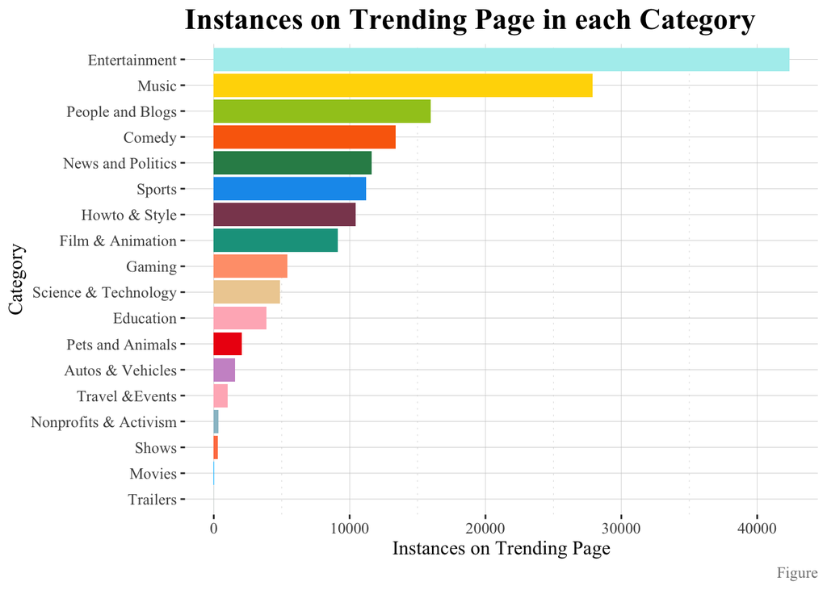

```r
youtube %>%
  group_by(category_id) %>%
  mutate(n = n()) %>%
  ggplot(aes(x = fct_reorder(category_id, n),
             fill = category_id)) +
  geom_bar(show.legend = FALSE) +
  labs(x = "Category",
       y = "Instances on Trending Page",
       title = "Instances on Trending Page in each Category",
       caption="Figure") +
  coord_flip()
```

Thus, we can see that “Entertainment” videos are the most frequent type of videos that appear on the trending list.

We can also see how the number of instances a category has appeared on the trending list has changed over time as well. Our data consists of trending videos from November of 2017 through June of 2018. Figure 2 below shows the number of trending videos over time in the categories “Entertainment,” “Music,” “People and Blogs,” “Comedy,” and “News and Politics”. These categories are the top five categories from Figure 1, whiched showed the categories with the most instances on the daily trending list.

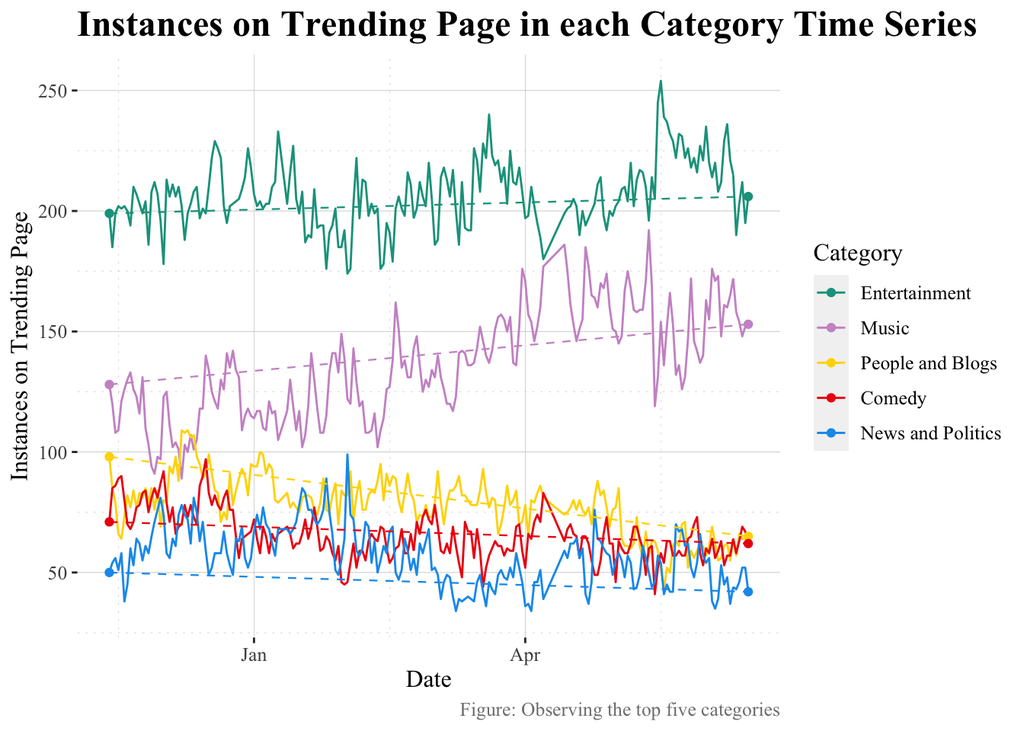

```r
left_right <- youtube %>%
  filter(category_id %in% c("Entertainment", "Music",
                            "People and Blogs", "Comedy",
                            "News and Politics")) %>%
  group_by(category_id, trending_date) %>%
  tally() %>%
  group_by(category_id) %>%
  slice(which.min(trending_date), which.max(trending_date))

youtube %>%
  filter(category_id %in% c("Entertainment", "Music",
                            "People and Blogs", "Comedy",
                            "News and Politics")) %>%
  group_by(category_id, trending_date) %>%
  tally() %>%
  ggplot() +
  geom_line(aes(x = trending_date,
                y = n,
                color = fct_reorder(category_id, desc(n)))) +
  geom_point(data = left_right,
             aes(x = trending_date,
                 y = n,
                 color = category_id)) +
  geom_line(data = left_right,
            aes(x = trending_date,
                y = n,
                color = category_id),
            linetype = "dashed",
            size = 0.40) +
  labs(x = "Date",
       y = "Instances on Trending Page",
       title = "Instances on Trending Page in each Category Time Series",
       color = "Category",
       caption = "Figure: Observing the top five categories") +
  scale_fill_discrete(name = "Category")
```

In analyzing Figure 2, we see that the number of instances of “Entertainment” stays relatively constant over time. Also, we see that the time series for “Entertainment” is the highest on the chart. This makes sense since “Entertainment” was by far the most frequent category to appear on the trending list (as seen in Figure 1). Our second most frequent category was “Music”. So, we would expect it to be the second highest on the time series chart, which it is. For “Music” videos, we see an increase starting around March and this increase continues into May. I conducted some additional research to explain this increase. According to what I found, many popular artists release new music around the spring because it gives the songs time to become popular before summer when people are outside more and playing music. This time frame also gives songs time to become popular before summer tours commence. For the bottom three categories of “People and Blogs,” “Comedy,” and “News and Politics,” we see that they all appear to initially stay constant and then collectively decrease as “Music” increases. This makes sense because there are only so many spots on the trending list. So, as one category increases, others would have to decrease.

One metric that YouTube uses to determine which videos are trending is the amount of views the video has. Figure 3 below shows the top five categories with the most views on their videos.

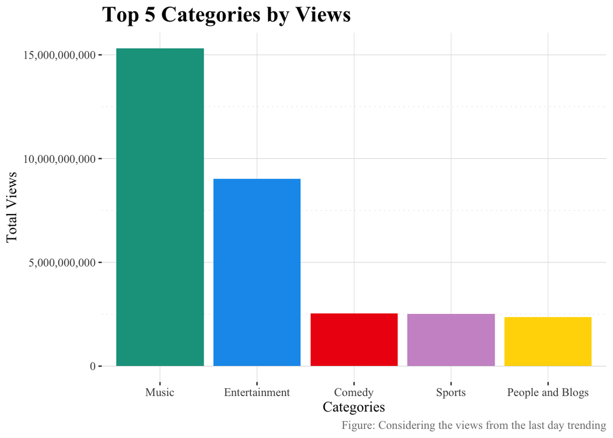

```r
youtube %>%
  group_by(video_id) %>%
  slice(which.max(trending_date)) %>%
  group_by(category_id) %>%
  summarise(total_views = sum(views, na.rm = T)) %>%
  arrange(desc(total_views)) %>%
  top_n(5) %>%
  ggplot(aes(x = fct_reorder(category_id, desc(total_views)),
             fill = category_id)) +
  geom_bar(aes(weight=total_views),
           show.legend = FALSE) +
  labs(x = "Categories",
       y = "Total Views",
       title = "Top 5 Categories by Views",
       caption = "Figure: Considering the views from the last day trending") +
  scale_y_continuous(labels = scales::comma)
```

In analyzing Figure 3, we see that the top 5 categories are the same as in Figure 2 except that “Sports” has replaced “News and Politics.” We see that “Music” has by far the highest amount of views, with the next highest category being “Entertainment.” In Figure 1, we found that the most frequent type of trending video was “Entertainment” so this result seems unintuitive. We would expect to see “Entertainment” with the most views since this category appears the most on the trending list. However, according to YouTube, new music releases are some of the most viewed videos on the site, even though they are not on the trending list as often as “Entertainment” videos. In looking at the most viewed videos in YouTube history, I found that 18 out of the top 20 are “Music” videos. Another explanation for why “Music” has more views than “Entertainment” is that we think people are more likely to replay a “Music” video, which would increase its views. It is not uncommon for someone to play a catchy song a few times, but for “Entertainment” videos, once you watch it, you usually do not get much more satisfaction watching it a second time, or at least not right away. So, this is just another possible reason for why the “Music” category has more views, even though there are more instances of “Entertainment” videos.

We can also analyze which categories prompt the most fan interaction. We can measure this by analyzing the amount of comments the videos in each category received. Figure 4 shows the top five categories by the amount of comments on their videos.

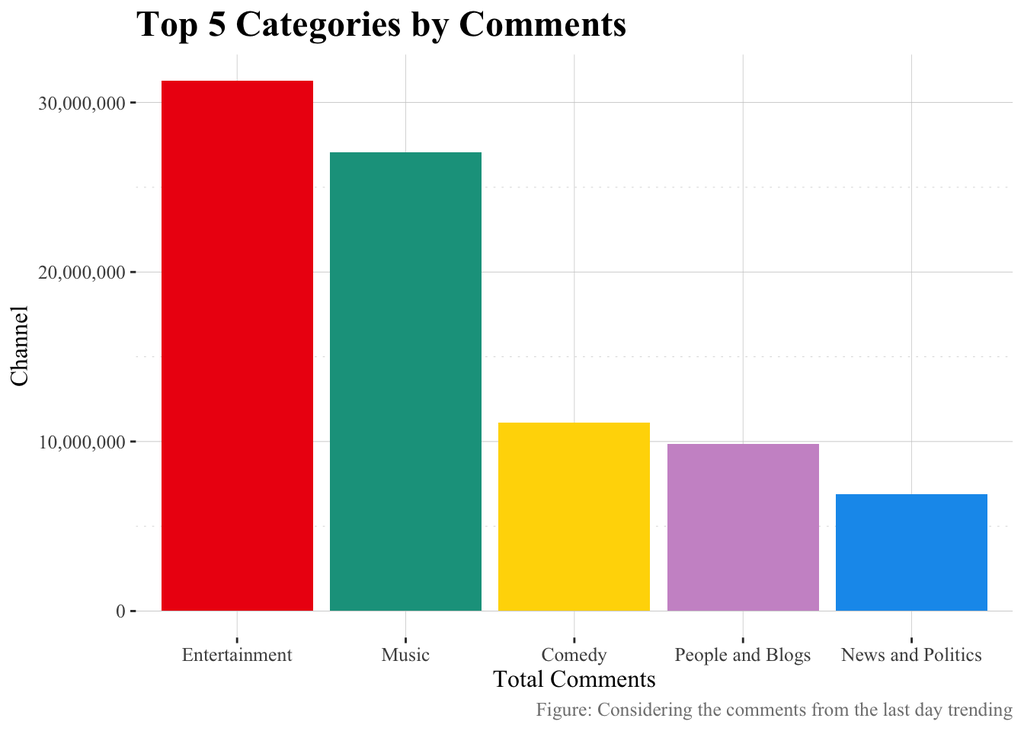

```r
youtube %>%
  group_by(video_id) %>%
  slice(which.max(trending_date)) %>%
  group_by(category_id) %>%
  summarise(total_comments = sum(comment_count)) %>%
  arrange(desc(total_comments)) %>%
  top_n(5) %>%
  ggplot(aes(x = fct_reorder(category_id, desc(total_comments)),
             fill = category_id)) +
  geom_bar(aes(weight = total_comments),
           show.legend = FALSE) +
  labs(x = "Total Comments",
       y = "Channel",
       title = "Top 5 Categories by Comments",
       caption = "Figure: Considering the comments from the last day trending") +
  scale_y_continuous(labels = scales::comma)
```

We can see that the categories in Figure 4 are the same as in Figure 2, except “Comedy” and “People and Blogs” have switched places. Also in Figure 4, we see that “Entertainment” has now overtaken “Music.” This result may seem unintuitive because we found in Figure 3 that “Music” has the most views. So, the more people watching a video, the more likely, you would think, they would be to leave a comment. However, if we consider the replay scenario mentioned in Figure 3’s analysis, we believe that a viewer is unlikely to comment each time they replay a video. Also, another explanation for why “Entertainment” has the highest comment count is because these videos may be more reactionary in nature and may even ask viewers to leave a comment, which a song is unlikely to do.